# unsuperv_prep

**The Insurance Dataset contains information about individuals, including demographic and health-related factors, and the corresponding insurance charges they incurred. The dataset consists of 7 features (columns) and multiple rows representing different individuals.**

**Features:**

- age: Age of the individual.
- sex: Gender of the individual (male/female).
- bmi: Body Mass Index, a measure of body fat based on height and weight.
- children: Number of children/dependents covered by the insurance.
- smoker: Whether the individual is a smoker (yes/no).
- region: Geographic region of the individual (northeast, northwest, southeast, southwest).
- charges: The amount charged by the insurance company (target variable).

**This dataset provides a diverse set of features that can influence insurance costs, such as age, gender, BMI, smoking status, and region. It’s commonly used for regression tasks, where the goal is to predict insurance charges based on the other features. It allows for the exploration of how lifestyle factors (like smoking) and demographics affect insurance pricing.**

```python
import numpy as np
import pandas as pd
from sklearn.model_selection import train_test_split
from sklearn.preprocessing   import StandardScaler
import matplotlib.pyplot as plt
import seaborn as sns


dataset = pd.read_csv('https://storage.googleapis.com/esmartdata-courses-files/ml-course/insurance.csv')

df = dataset.copy()
```

**Basic information about the dataset, such as the number of entries, data types of each column, and non-null counts.**

```python
print(df.info())
```

```
<class 'pandas.core.frame.DataFrame'>
RangeIndex: 1338 entries, 0 to 1337
Data columns (total 7 columns):
 #   Column    Non-Null Count  Dtype
---  ------    --------------  -----
 0   age       1338 non-null   int64
 1   sex       1338 non-null   object
 2   bmi       1338 non-null   float64
 3   children  1338 non-null   int64
 4   smoker    1338 non-null   object
 5   region    1338 non-null   object
 6   charges   1338 non-null   float64
dtypes: float64(2), int64(2), object(3)
memory usage: 73.3+ KB
None
```

## Inspecting the categorical variables

**Showing how the categorical data (sex, smoker, and region) is distributed across these categories.**

```python
print(df['sex'].value_counts())
print(df['smoker'].value_counts())
print(df['region'].value_counts())
```

```
sex
male      676
female    662
Name: count, dtype: int64
smoker
no     1064
yes     274
Name: count, dtype: int64
region
southeast    364
southwest    325
northwest    325
northeast    324
Name: count, dtype: int64
```

## Converting object types

**Converting all columns with object types into categorical data, which makes it easier to encode them later.**

```python
for col in df.columns:
    if df[col].dtype == 'object':
        df[col] = df[col].astype('category')
df.info()
```

```
<class 'pandas.core.frame.DataFrame'>
RangeIndex: 1338 entries, 0 to 1337
Data columns (total 7 columns):
 #   Column    Non-Null Count  Dtype
---  ------    --------------  -----
 0   age       1338 non-null   int64
 1   sex       1338 non-null   category
 2   bmi       1338 non-null   float64
 3   children  1338 non-null   int64
 4   smoker    1338 non-null   category
 5   region    1338 non-null   category
 6   charges   1338 non-null   float64
dtypes: category(3), float64(2), int64(2)
memory usage: 46.3 KB
```

## Handling duplicates

**Duplicate rows, if any, are identified and removed using drop_duplicates(). Removing duplicates is crucial because they can introduce bias in the model training process, leading to inaccurate predictions.**

```python
df[df.duplicated()]
df.drop_duplicates(inplace=True)
df.info()

df.isnull().sum()
```

```
<class 'pandas.core.frame.DataFrame'>
Index: 1337 entries, 0 to 1337
Data columns (total 7 columns):
 #   Column    Non-Null Count  Dtype
---  ------    --------------  -----
 0   age       1337 non-null   int64
 1   sex       1337 non-null   category
 2   bmi       1337 non-null   float64
 3   children  1337 non-null   int64
 4   smoker    1337 non-null   category
 5   region    1337 non-null   category
 6   charges   1337 non-null   float64
dtypes: category(3), float64(2), int64(2)
memory usage: 56.6 KB
```

```
age         0
sex         0
bmi         0
children    0
smoker      0
region      0
charges     0
dtype: int64
```

## One-hot encoding

We use one-hot encoding to convert categorical variables into numerical form. We drop the first category to avoid multicollinearity (i.e., if one category is dropped, the others will carry the necessary information).

```python
df = pd.get_dummies(df, drop_first=True, dtype='int')
df
df.info()
```

```
<class 'pandas.core.frame.DataFrame'>
Index: 1337 entries, 0 to 1337
Data columns (total 9 columns):
 #   Column            Non-Null Count  Dtype
---  ------            --------------  -----
 0   age               1337 non-null   int64
 1   bmi               1337 non-null   float64
 2   children          1337 non-null   int64
 3   charges           1337 non-null   float64
 4   sex_male          1337 non-null   int32
 5   smoker_yes        1337 non-null   int32
 6   region_northwest  1337 non-null   int32
 7   region_southeast  1337 non-null   int32
 8   region_southwest  1337 non-null   int32
dtypes: float64(2), int32(5), int64(2)
memory usage: 78.3 KB
```

## **Histogram: Shows the distribution of charges (insurance costs).**

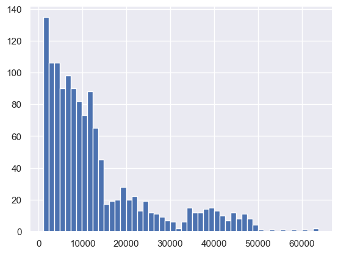

```python
plt.hist(df['charges'], bins=50)
```

## **Histogram: Shows the distribution of binary variable (smoker).**

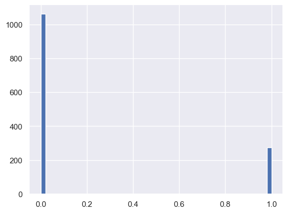

```python
plt.hist(df['smoker_yes'], bins=50)
```

## **Pie Chart: Visualizes the distribution of male and female customers.**

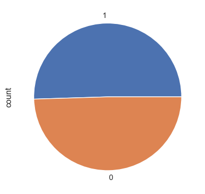

```python
df.sex_male.value_counts().plot(kind='pie')
```

## Correlation matrix

**Tthe correlation matrix, shows the strength and direction of the relationships between each pair of variables. Positive correlations indicate that as one variable increases, so does the other, while negative correlations indicate an inverse relationship.**

```python
corr = df.corr()
corr
```

|  | age | bmi | children | charges | sex_male | smoker_yes | region_northwest | region_southeast | region_southwest |
| --- | --- | --- | --- | --- | --- | --- | --- | --- | --- |
| age | 1.000000 | 0.109344 | 0.041536 | 0.298308 | -0.019814 | -0.025587 | 0.001495 | -0.012311 | 0.009415 |
| bmi | 0.109344 | 1.000000 | 0.012755 | 0.198401 | 0.046397 | 0.003746 | -0.136138 | 0.270057 | -0.006211 |
| children | 0.041536 | 0.012755 | 1.000000 | 0.067389 | 0.017848 | 0.007331 | 0.026044 | -0.023492 | 0.021538 |
| charges | 0.298308 | 0.198401 | 0.067389 | 1.000000 | 0.058044 | 0.787234 | -0.038695 | 0.073578 | -0.043637 |
| sex_male | -0.019814 | 0.046397 | 0.017848 | 0.058044 | 1.000000 | 0.076596 | -0.012482 | 0.017578 | -0.003767 |
| smoker_yes | -0.025587 | 0.003746 | 0.007331 | 0.787234 | 0.076596 | 1.000000 | -0.036321 | 0.068282 | -0.037168 |
| region_northwest | 0.001495 | -0.136138 | 0.026044 | -0.038695 | -0.012482 | -0.036321 | 1.000000 | -0.345909 | -0.320493 |
| region_southeast | -0.012311 | 0.270057 | -0.023492 | 0.073578 | 0.017578 | 0.068282 | -0.345909 | 1.000000 | -0.346614 |
| region_southwest | 0.009415 | -0.006211 | 0.021538 | -0.043637 | -0.003767 | -0.037168 | -0.320493 | -0.346614 | 1.000000 |

## Correlation Bar Plot

**The horizontal bar plot of the correlation between each variable and the charges column (insurance cost). It highlights which variables have the strongest positive or negative correlation with the target variable.**

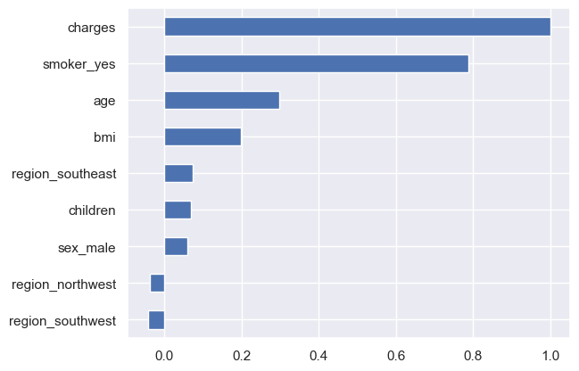

```python
df.corr()['charges'].sort_values(ascending=False)
sns.set()
df.corr()['charges'].sort_values(ascending=True).plot(kind='barh')
```

```python
X = df.copy()
y = X.pop('charges')

X.head()
y.head()

scaler = StandardScaler()
X = scaler.fit_transform(X)
X_train, X_test, y_train, y_test = train_test_split(X,y,test_size=0.2)
```